# Microcredencial “agRo-al” - Session 7 | [Back to HOME](https://agro-al.github.io)

### Basic arithmetics on numeric objects

There are a bunch of **R** functions to manipulate data. We have already seen some examples of them in previous sessions (**arithmetic operators**). The numeric vectors can be manipulated with classical arithmetic expressions such as adding, subtracting, multiplying and division. However, these examples are minimal compared to the great potential of **R** to execute simple and complex mathematical operations.

For practical reasons, we cannot review all the arithmetic operations and functions available in **R** base. Notwithstanding, we will review the most common and relevant ones to extract relevant information from our data.

Let’s load into the **R** environment our BEDCA dataset created and written during the last session. Previous to starting the file reading, remember to set your environment in the proper **working directory** or properly declare the **path** to access and read the *BEDCA_dataset.csv* file:

```
## Reading the file for practice
mydata <- read.table("BEDCA_dataset.csv", header = T, sep ="\t", row.names = "food_id")

## Evaluating attributes on my object
class(myadata)
dim(mydata)

## Inspect the recorded variables for every observation in the data frame
colnames(mydata)
```

*Example # 1*

One of the variables contained in the dataset records the total amount of kcal. So, let’s evaluate the attributes of this particular vector first:

```
## Attribute evaluation
mode(mydata$Energy_.kcal.)

length(mydata$Energy_.kcal.)

is.na(mydata$Energy_.kcal.)
```

In nutrition, sometimes is interesting to declare total energy content in terms of *kj* (Kilojoules) to adjust to SI unit of energy. Then, and assuming *1 kcal = 4.184 kj*, create a new column in the dataset with the standardized measured of energy.

`mydata$Energy.kj <- mydata$Energy_.kcal. * 4.184`

*Example # 2*

```
mydata$Carb2Prot <- mydata$Sugars_total_.g. / mydata$Protein_.g.
```

*Example # 3*

If you take a look at the dataset, there are several variables described as different variants of *“Fatty acids”*. Even more, there are some variables describing the *“total”* amount discriminated by the level of saturation. However, there is no one variable reporting the global content of *Fatty acids*, disregarding the saturation or class. So, we need to create a new variable with this information. This can be done in a more elegant manner:

```
## Detecting the variables to sum up
startsWith(colnames(mydata), "Fatty_acid_total")

## Indexation of the positions in the vector
mylabels <- which(startsWith(colnames(mydata), "Fatty_acid_total"), colnames(mydata))

## Executing the sum of all variables selected
mydata$Total.FA <- rowSums(mydata[,mylabels], na.rm = T)
```

The above consists of a very small example of how to implement mathematical functions in our dataset to rescue particular information and to create new ones of interest. Below, there is a list of other functions that may be useful for different purposes. Try them for any of the variables present in the *BEDCA dataset*.

- *sum(x)*: sum of the *x*’s elements.
- *prod(x)*: product of the *x*’s elements.
- *log(x, base)*: computes the logarithm of *x*’s elements with a given base.
- *log10(x)*: base 10 logarithm of the *x*’s elements.
- *log2(x)*: base 2 logarithm of the *x*’s elements.
- *sqrt(x)*: square-root of the *x*’s elements.
- *abs(x)*: computes the absolute value of *x*’s elements.
- *cos(x)*, *sin(x)*, and *tan(x)*: trigonometric functions for computing cosine, sine, and tangent of *x*’s elements.

### Another simple functions of interest

In addition to the above-mentioned strictly mathematical functions, there are several others of equal interest to manipulate your data in different ways. They’re more related to **element indexation** when exploring them from the mathematical point of view:

- *max(x)*: maximum or the largest of the *x*’s elements.
- *min(x)*: minimum or the smallest of the *x*’s elements.
- *which.max(x)*: returns the index of the greatest *x*’s element.
- *which.min(x)*: returns the index of the smallest *x*’s element.
- *round(x, n)*: it rounds the elements of *x* to *n* decimals positions.
- *rev(x)*: reverses the *x*’s elements.
- *sort(x)*: sorts the *x*’s elements in increasing order, for ordering in decreasing order, *rev(sort(x))*.
- *rank(x)*: ranks the numbers (in increasing order) in the *x* vector.
- *rank(-x)*: ranks the numbers (in decreasing order) in the *x* vector.
- *which(x == y)*: returns a vector of arithmetic or logical comparisons according to the operator type used.
- *match(x, y)*: returns a vector of the same length than *x* with its elements being in *y*.
- *na.omit(x)*: removes the observations with missing data (NA).

Try the above listed functions on our *BEDCA dataset* to gain experience in their implementation.

### Statistical functions

Statistical analysis is probably the most valuable asset for using R. In addition to the multiple functions compiled in the *base* installation, the massive functions implemented in *CRAN* packages permit to access to a wide array of different mathematical and statistical methods of analysis, making it superior when compared to other similar platforms for data analysis.

In the graph below, there is a wide selection of statistical methods implemented in the **R** *base*, and they compile all possible analyses in agreement with your study design (normal/non-normal distributed data, categorical data, two-group or multi-group, correlation or regression).

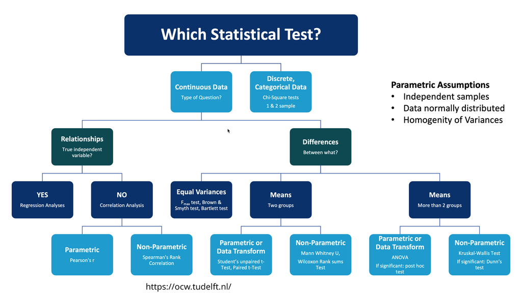

**IMPORTANT**: Before reviewing different statistical approaches and functions, it is essential to define the concept of *Formula*, a recurrent argument requested when exploring data through statistical methods and functions implemented in **R**.

*Formulae* are key elements in **R** statistics. Such notation used is the same for (almost) all functions implemented in **R**. A *formula* typically adopts the *y ~ model* form, where *y* is the analysed response and *model* is a set of terms (preferentially categorical but not exclusively) for which some parameters are to be estimated. These terms are separated with arithmetic symbols, each with a particular meaning. For instance:

- *a + b*: expresses the **additive** effects of *a* and of *b* (effect of *a* variable on the outcome is independent of *b* variable)
- *a : b*: indicates an **interactive** effect between *a* and *b* variables (effect of the *a* variable depends on the presence of *b* variable)
- *a * b*: expresses **additive** and **interactive** effects (similar to the *a + b* **+** *a : b* notation)
- *^ n*: it includes all interactions up to level *n*. For instance, *(a + b + c) ^ 2* is equivalent to (*a + b + c* **+** *a : b* **+** *a : c* **+** *b : c*).

**Especial cases**. For analyses of variance, *aov()*, the formula notation accepts a particular syntax to define random effects (**covariate control**). For instance, *y ~ a + Error(b)* means the additive effects of the fixed term *a* and the random one *b*. This similar control on random effects adopt the following notation in advance analysis models (e.g. linear mixed models): *y ~ a + (1 | b)*.

Here’s a selection of statistical functions installed with the *R base* and related to measures of central tendency, dispersion and proportions:

- *mean(x)*: mean or average of the *x*’s elements.
- *median(x)*: median of the *x*’s elements.
- *sd(x)*: computes the standard deviation of the *x*’s elements.
- *var(x)*: calculates the variance across the *x*’s elements.
- *scale(x)*: centers and reduces the data. *center* or *scale* can be modified accordingly. In summary, it computes standard scores (z-scores).
- *quantile(x)*: computes the 0th, 25th, 50th, 75th, and 100th percentiles of the *x* elements distribution.
- *confint(x)*: calculates the confidence intervals for the *x* elements distribution. Uses linear model (*lm*) by default.

*BONUS TRACK*: for any reason, **R base** does not contain a particular function to compute the standard error of the mean (SEM), a statistical parameter frequently used in data science. But there is no problem, as early steps in your future as **R developer**, you can built from scratch any novel function in **R** to implement on your data:

```
sem <- function(x){
                     sd(x) / sqrt(length(x))
                     }
```

Now, your environment should contain a novel *Function* that you can call as:

`sem(x)`

Aside from the above-stated basic statistical functions, there is also a large inventory of tests and analyses for *contrasting hypotheses* and looking for *associations* and *correlations*. Most of them return an *object* of *class* with the same name (e.g., aov returns an object of class *“aov”*, glm returns one of class *“glm”*). The functions we can use to extract the results will act specifically with regard to the object class. These functions are called generic and the most widely used are:

- *print*: returns a brief summary of the outcome
- *summary*: returns a detailed summary of the object generated
- *coef*: returns the estimated coefficients
- *residuals*: returns the computed residuals

Now, let’s try to generate objects from the following functions and explore the results obtained. For such an aim, we will create *subsets* of data containing **two** and **three** categorical variables (“food_group” column name) from *mydata* data frame (955 obs. x 52 var.) as follows:

```
# Subset containing two levels from "food_group"
mydatax2var <-  subset(mydata, food_group == "Fats_and_oils" | food_group == "Fruits_and_fruit_products")

# Subset containing three levels from "food_group"
mydatax3var <-  subset(mydata, food_group == "Fats_and_oils" | food_group == "Fruits_and_fruit_products" | food_group == "Milk_and_milk_products")
```

**Normality tests**

- *shapiro.test(x)*: computes the *Shapiro-Wilk* normality test on the *x* vector of elements.
- *ks.test(x, y)*: perform the *Kolmogorov-Smirnov* test on *x* elements under the *y* cumulative distribution (“pnorm” by default).

```
# Example
shapiro.test(mydata$Energy.kj)
```

**Two-group comparisons under normality assumption**

- *t.test(x, y)*: under normal distributed *x* elements, it computes the *Student’s t-Test* of *x* elements across a *y* grouping variable. Other central arguments to setup are: *alternative*, *paired*, *var.equal* (see help for more details).
- *pairwise.t.test(x, y)*: assuming normality of the *x* elements, it calculates pairwise comparisons of *x* elements between all possible group level (*y*) pairs. It is important to define also the following *p.adjust*, *paired*, *alternative* function arguments.

```
# Example
t.test(mydatax2var$Energy.kj ~ as.factor(mydatax2var$food_group))

pairwise.t.test(mydatax3var$Energy.kj , as.factor(mydatax3var$food_group), p.adjust = "fdr", na.rm = T, paired = F)
```

**Multiple-group comparisons under normality assumption**

- *aov(x ~ y)*: it performs an analysis of variance of *x* elements across *y* grouping variable based on a linear model. The formula (x ~ y) can adopt any optional model including covariation (x ~ y + a * z). The *data* argument must be defined.

```
# Example
# Testing Energy.kj variation across experimental groups
aov(Energy.kj ~ food_group, data = mydatax3var)

# Extracting more structured and human-readable information
summary(aov(Energy.kj ~ food_group, data = mydatax3var))

# Exploring additive effects of additional variables
summary(aov(Energy.kj ~ food_group + Total.FA, data = mydatax3var))

# Assuming and controlling covariation
summary(aov(Energy.kj ~ food_group + Error(Total.FA), data = mydatax3var))
```

**Non-parametric two-group comparisons**

- *wilcox.test(x, y)*: assuming non-parametric *x* distribution, it computes rank-based comparison of *x* elements between *y* groups. Also know as **Mann-Whitney test**. Other arguments to define are *alternative*, *paired* (defining execution of **Rank Sum**-unpaired or **Signed Rank**-paired tests), and *exact* if ties are present in *x*.
- *pairwise.wilcox.test()*: when *x* is non-parametrically distributed, it computes **Wilcoxon test** on each pairwise comparisons of *x* elements between all possible group level (*y*) pairs. It is important to define also the following *p.adjust*, *paired*, *alternative*, and *exact* function arguments.

```
# Example
wilcox.test(mydatax2var$Energy.kj ~ mydatax2var$food_group)

pairwise.wilcox.test(mydatax3var$Energy.kj, mydatax3var$food_group, exact = F, p.adjust = "fdr")
```

**Non-parametric multiple-group comparisons**

- *kruskal.test(x, y)*: it performs the **Kruskal-Wallis** rank sum test to detect *x* mean differences across more tha two groups (*y*). Besides the formula, the *data* argument is also required.

```
# Example
kruskal.test(mydatax3var$Energy.kj, mydatax3var$food_group, exact = F)
```

**Alternative methods to measure group differences**

- *bartlett.test(x ~ y)*: it computes the **Bartlett’s test** of homogeneity of *x* variances across *y* groups. As the *x* and *y* arguments adopt a formula mode, *data* needs to be declared.

```
# Example
bartlett.test(Energy.kj ~ food_group, data = mydatax3var)
```

**Methods assessing associations and relationships**

- *cor.test(x, y)*: it performs regression and correlation analyses between paired samples. The *alternative* argument must be declared at convenience. The *method* argument will vary from declaring *“pearson (r)”*, *“spearman (rho)”*, or *“kendall (tau)”*, these last two for non-parametric data also demanding *exact* declaration for **ties** control.

```
# Example
cor.test(mydata$Energy.kj, mydata$Total.FA, method = "pearson")

cor.test(mydata$Energy.kj, mydata$Total.FA, method = "spearman", exact = F)

cor.test(mydata$Energy.kj, mydata$Total.FA, method = "kendall", exact = F)
```

**Assessment of discrete and categorical variables**

- *fisher.test(x, y)*: it computes the **Fisher’s exact** to test independence of rows and columns in a contingency table. If data *x* is a 2 x 2 matrix, then *y* (factor) is not needed. Additional arguments to control includes *alternative* and *simulate.p.value* to include Monte Carlo simulation. As **Fisher test** work on computing factorials, it may not work properly for large sample sizes and results computationally less efficient.
- *chisq.test(x, y)*: it performs the **Goodness-of-fit** test. It uses same inputs and control similar arguments than *fisher.test* (e.g. *alternative*, *simulate.p.value*). By default, *chisq.test* introduces the **Yates’s correction** to preventing overestimation of statistical significance for small data (one cell count > 5). If the **Monte Carlo** simulation is activated, the **Yates’s correction** will be obviated.

```
# Example
# Creating a new categorical variable - logic evaluation of total fat content (higher/lower 50 g per 100 g)
mydatax2var$Fat.content <- mydatax2var$Total.FA > 50
mydatax2var$Fat.content

# Using cross-classifying factors (*table* function) to build a matrix

table(as.factor(mydatax2var$Fat.content):as.factor(mydatax2var$food_group))

# Now we arrange such information into a matrix
mycontigency.table <- matrix(table(as.factor(mydatax2var$Fat.content):as.factor(mydatax2var$food_group)), nrow = 2, ncol = 2, byrow = T)

# Adding column labels to the matrix indexing factor levels
colnames(mycontigency.table) <- c(levels(as.factor(mydatax2var$food_group))[1], levels(as.factor(mydatax2var$food_group))[2])

# Adding row labels to the matrix indexing "fat content" levels
rownames(mycontigency.table) <- c("Low.fat", "High.fat")

# Inspecting the matrix object created
View(mycontigency.table)

# Executing Chi-square test with Monte-Carlo simulation
chisq.test(mycontigency.table, simulate.p.value = T)
```